# sentimentAnalysis_compare

Sentiment Analysis of Public Opinion on Gluten-Free food displayed over Reddit

```python
#Import packages
import pandas as pd
import numpy as np
import matplotlib.pyplot as plt
import seaborn as sns
import os
reddit_data=pd.read_csv("")
```

Start by comparing two well-known sentiment analyzers: Textblob and VADER

Initial Hypotheses:

There seems to exist a certain stigma surrounding the GF lifestyle. Several factors contribute to this. For one, few people truly understand there is a difference between having Celiac disease (an intestinal disorder) and choosing to eat on a GF diet (perceived to be healthier or softer on the stomach for some people). Additionally, the GF diet, which is generally less fatal than a peanut/dairy allergy, is closely associated with more trendy, millenium movements. It's viewed largely as a fad. Thus, I, as a Celiac-patient, expect to see a more negative outlook on reddit, both from people who struggle with Celiac and those who look down on the lifestyle.

```python
# TextBlob
from textblob import TextBlob
#Textblob is less nuanced than VADER, but it can be useful for basic sentiment analysis.

reddit_textblob = reddit_data.copy()
# Assuming 'reddit_data' has a column named 'body' containing the Reddit post content
if 'body' in reddit_textblob.columns:
    # Perform sentiment analysis
    reddit_textblob['body'] = reddit_textblob['body'].fillna('').astype(str)

    reddit_textblob['polarity'] = reddit_textblob['body'].apply(lambda x: TextBlob(x).sentiment.polarity)
    reddit_textblob['subjectivity'] = reddit_textblob['body'].apply(lambda x: TextBlob(x).sentiment.subjectivity)

    # Display the first few rows with sentiment scores
    print(reddit_textblob[['body', 'polarity', 'subjectivity']])

    # Save the results to a new CSV file
    reddit_textblob.to_csv("reddit_textblob.csv", index=False)
else:
    print("The 'body' column is missing in the dataset.")
```

```
                                                   body  polarity  \
0     … as I’ve found out over the last 4 months. \n...  0.029533
1                                                        0.000000
2     I will pre-empt that I am only one celiac, and...  0.142937
3     Apologies for my ignorance; I ask because I tr... -0.002557
4     So i've been very unwell the last few months w... -0.001936
...                                                 ...       ...
4695  Over the past two months, I have been experien... -0.016762
4696  \nI feel like I’m crazy. 26F. I’ve been compla... -0.039588
4697  I can’t eat any gluten anymore. And I live in ...  0.129450
4698  I'm in tears as I type this because I'm just s... -0.159460
4699  Alright guys. So I dont know how many of you h...  0.500000

      subjectivity
0         0.659640
1         0.000000
2         0.490505
3         0.386364
4         0.562037
...            ...
4695      0.478257
4696      0.451922
4697      0.507143
4698      0.562778
4699      0.500000

[4700 rows x 3 columns]
```

Polarity: [-1,1] --> quantifies the positivity/negativity of a reddit post Subjectivity: [0,1] --> quantifies whether the post expresses more opinionated or factual information

We expect initially that subjectivity scores closer to 1, as people will be writing in either an excited or frustrated tone. Social media is often used to share frustrations or bond over shared emotions. If this were a GF food blog, we'd see more factual information and statistics.

```python
#VADER
# VADER (Valence Aware Dictionary and sEntiment Reasoner) is a lexicon and rule-based sentiment analysis tool
# that is particularly effective for social media text.
import nltk
#nltk.download('vader_lexicon')

from nltk.sentiment import SentimentIntensityAnalyzer

# Initialize VADER sentiment analyzer
sia = SentimentIntensityAnalyzer()

reddit_vader = reddit_data.copy()

reddit_vader['body'] = reddit_vader['body'].fillna('').astype(str)

reddit_vader['vader_scores'] = reddit_vader['body'].apply(lambda x: sia.polarity_scores(x))
reddit_vader['vader_compound'] = reddit_vader['vader_scores'].apply(lambda score_dict: score_dict['compound'])
reddit_vader['vader_neg'] = reddit_vader['vader_scores'].apply(lambda score_dict: score_dict['neg'])
reddit_vader['vader_neu'] = reddit_vader['vader_scores'].apply(lambda score_dict: score_dict['neu'])
reddit_vader['vader_pos'] = reddit_vader['vader_scores'].apply(lambda score_dict: score_dict['pos'])

# Classify sentiment based on compound score
def classify_vader_sentiment(score):
        if score >= 0.05: #0.05 is the threshold for positive sentiment
            return 'positive'
        elif score <= -0.05:
            return 'negative'
        else:
            return 'neutral'

reddit_vader['vader_label'] = reddit_vader['vader_compound'].apply(classify_vader_sentiment)

    # Display results
print(reddit_vader[['body', 'vader_compound', 'vader_neg', 'vader_neu', 'vader_pos', 'vader_label']].head())

# Save to CSV
reddit_vader.to_csv("reddit_vader.csv", index=False)
```

```
                                                body  vader_compound  \
0  … as I’ve found out over the last 4 months. \n...         -0.9850
1                                                             0.0000
2  I will pre-empt that I am only one celiac, and...          0.9952
3  Apologies for my ignorance; I ask because I tr...          0.8767
4  So i've been very unwell the last few months w...          0.9793

   vader_neg  vader_neu  vader_pos vader_label
0      0.184      0.689      0.128    negative
1      0.000      0.000      0.000     neutral
2      0.101      0.749      0.150    positive
3      0.031      0.814      0.155    positive
4      0.108      0.709      0.183    positive
```

```python
#Compare VADER and TextBlob
# Calculate average polarity from TextBlob
textblob_avg_polarity = reddit_textblob['polarity'].mean()

# Calculate average compound score from VADER
vader_avg_compound = reddit_vader['vader_compound'].mean()

# Print the results
print(f"Average Polarity (TextBlob): {textblob_avg_polarity}")
print(f"Average Compound Score (VADER): {vader_avg_compound}")

# Compare the two
if textblob_avg_polarity > vader_avg_compound:
    print("TextBlob shows a more positive sentiment on average.")
elif textblob_avg_polarity < vader_avg_compound:
    print("VADER shows a more positive sentiment on average.")
else:
    print("Both TextBlob and VADER show the same average sentiment.")
```

```
Average Polarity (TextBlob): 0.10624893191421707
Average Compound Score (VADER): 0.3548161489361702
VADER shows a more positive sentiment on average.
```

The above result is somewhat surprising. These scores are normalized between -1 and 1, with 1 ~ positive and -1 ~ negative.

For both TextBlob Polarity and VADER Compound, the mean scores are positive. Again, the VADER analyzer is more attuned to social media, where slang words and punctuation use imply something slightly different than traditional writing. Generally, we take VADER to be the more accurate analyzer in the context of Reddit.

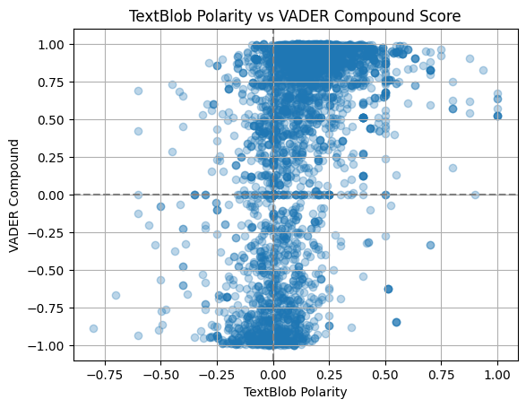

```python
import matplotlib.pyplot as plt

plt.scatter(reddit_textblob['polarity'], reddit_vader['vader_compound'], alpha=0.3)
plt.title("TextBlob Polarity vs VADER Compound Score")
plt.xlabel("TextBlob Polarity")
plt.ylabel("VADER Compound")
plt.grid(True)
plt.axhline(0, color='grey', linestyle='--')
plt.axvline(0, color='grey', linestyle='--')
plt.show()
```

Let's compare the average compound scores by subreddit. The 6 subreddit pages being investigated are:

- r/celiac
- r/glutenfree
- r/diet
- r/food
- r/autoimmune
- r/recipes

I'd expect the 'celiac' and 'glutenfree' subreddits, which are dedicated only to the allergy, to be most hostile. These pages separate the GF community, and likely serve as a place to vent or ask for help with dealing with GF. On the other hand, the other subreddits are more general. GF topics are only a fraction of the 'diet' or 'food' conversation, for example, so these posts involving GF are often from a curiosity perspective. People may ask about GF recipes without complaining or sharing their difficulties they way they would in a dedicated space.

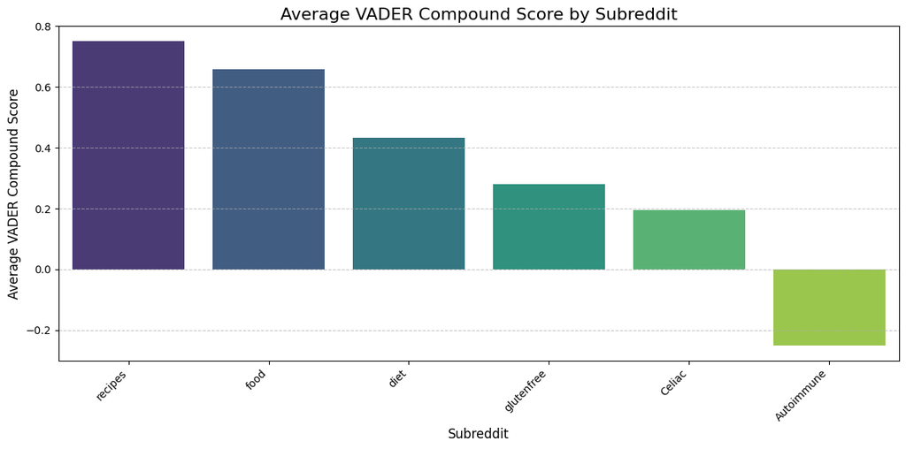

```python
import matplotlib.pyplot as plt
import seaborn as sns

# Group by subreddit and calculate the average vader_compound score
average_vader_by_subreddit = reddit_vader.groupby('subreddit_name')['vader_compound'].mean().reset_index()
average_vader_by_subreddit.columns = ['subreddit_name', 'average_vader_compound']

# Sort by average compound score for better visualization
average_vader_by_subreddit = average_vader_by_subreddit.sort_values(by='average_vader_compound', ascending=False)

# Plot the bar chart
plt.figure(figsize=(12, 6))
sns.barplot(data=average_vader_by_subreddit, x='subreddit_name', y='average_vader_compound', hue='subreddit_name', palette='viridis')
# Add labels and title
plt.title('Average VADER Compound Score by Subreddit', fontsize=16)
plt.xlabel('Subreddit', fontsize=12)
plt.ylabel('Average VADER Compound Score', fontsize=12)
plt.xticks(rotation=45, ha='right', fontsize=10)
plt.grid(axis='y', linestyle='--', alpha=0.7)

# Show the plot
plt.tight_layout()
plt.show()
```

A lot to unpack here

Notice the highly positive sentiments are identified in the r/recipes and r/food subreddits, with less positive feelings exuded by r/glutenfree and r/Celiac. The negative sentiment is expressed in r/Autoimmune. A few potential explanations: In a subreddit dedicated to recipes and general food (not specific to a GF diet), consider how gluten free is mentioned. If someone is sharing a recipe, they'd likely be excited--"Just found this amazing GF banana bread recipe!"--, or maybe a restaurant recommendation in r/food --"You should try Wildfire for the GF bread!"--. In these cases, Reddit posters would be more enthusiastic. If one were asking a question --"Where can I find GF hamburger buns"--, the sentiment analyzer may pick up an inquisitive tone. Now think about subreddit channels that are dedicated to glutenfree and Celiac. These are narrower communities, where a majority of posts might come from people who have Celiac Disease or follow a GF diet. Given how social media is, we might expect people to use these communities as a safe space to bond over or vent about their struggles (see some of the below samples). Hence, these subreddits yield lower scores. HOWEVER, these scores are still reading as positive. Low, but positive. Thus, the sentiment analyzer is picking up a net positive feeling--maybe because people support each other, too on these subreddits. As far as r/Autoimmune, any post made about gluten-free is quite likely to come from someone who is first adjusting, or even someone who is looking for answers. Perhaps people describing symptoms and asking if they might be experiencing Celiac Disease. In any case, people are more likely to be upset when on the subject of autoimmune disorders.

```
subreddit_name
glutenfree    1408
celiac        1385
recipes        789
diet           596
food           312
autoimmune     210
Name: count, dtype: int64
```

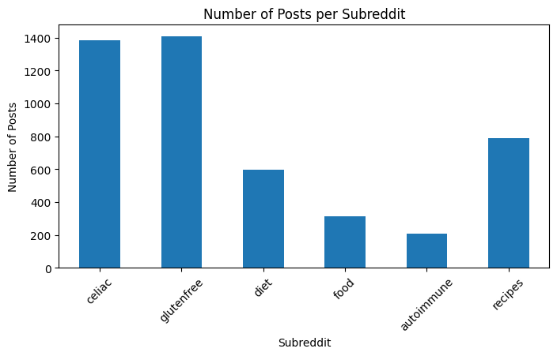

```python
# Check for class imbalance by counting posts per subreddit
subreddit_counts = reddit_data['subreddit_name'].str.lower().value_counts()
print(subreddit_counts)

# Optional: visualize the distribution
import matplotlib.pyplot as plt

plt.figure(figsize=(8, 4))
subreddit_counts.loc[subreddits].plot(kind='bar')
plt.title('Number of Posts per Subreddit')
plt.xlabel('Subreddit')
plt.ylabel('Number of Posts')
plt.xticks(rotation=45)
plt.show()
```

Additionally, let's note we do have a class imbalance dilemma here - In our gluten-free keyword dataset, r/glutenfree and r/Celiac had the highest volume of relevant posts — likely because GF topics are central to those communities. Thus, there would be more robust data after querying keywords like "glutenfree", "GF", and "Celiac"

More general subreddits, like r/food or r/recipes are less tailored to our specific subject. Still, we should still have an adequate number of samples in each subreddit to trust our VADER compound scores, as each subreddit's score is evaluated independently from the others

```python
from scipy.stats import ttest_ind

# Filter for the two subreddits from the full dataset
gf = reddit_vader[reddit_vader['subreddit_name'].str.lower() == 'glutenfree']['vader_compound']
food = reddit_vader[reddit_vader['subreddit_name'].str.lower() == 'food']['vader_compound']

#T-test to compare the VADER compound scores between the two subreddits
t_stat, p_val = ttest_ind(gf, food, equal_var=False)

print("T-statistic:", t_stat)
print("P-value:", p_val)
```

```
T-statistic: -12.43332515343401
P-value: 1.0280340869216055e-31
```

```python
from scipy.stats import ttest_ind

# Try two different subreddits, e.g., 'celiac' vs 'diet'
celiac = reddit_vader[reddit_vader['subreddit_name'].str.lower() == 'celiac']['vader_compound']
diet = reddit_vader[reddit_vader['subreddit_name'].str.lower() == 'diet']['vader_compound']

#T-test to compare the VADER compound scores between the two subreddits
t_stat, p_val = ttest_ind(celiac, diet, equal_var=False)

print("T-statistic:", t_stat)
print("P-value:", p_val)
```

```
T-statistic: -7.3095016693122234
P-value: 4.85502943626539e-13
```

The above statistical results imply the results from comparing different subreddits and their compound sentiment scores are very trustworthy (not occuring by chance). We can use this to further defend against the risks of class imbalance.

NOTE: These p-values will be inspected further, as they are quite low. That being said, they are consistently about 0 for different subreddit comparisons. Additionally, remember the data extraction does not always obtain the exact formatting or content of each post. There can be grammatical or data-collection errors that influence these results

We will sample some posts below (note the output may be truncated)

```python
import pandas as pd

# List of subreddits to sample from (case-insensitive)
subreddits = ['celiac', 'glutenfree', 'diet', 'food', 'autoimmune', 'recipes']

# Collect samples in a list of dicts, skipping NaN bodies
samples = []
for subreddit in subreddits:
    sample_rows = reddit_data[
        (reddit_data['subreddit_name'].str.lower() == subreddit) &
        (reddit_data['body'].notna())
    ].head(3)
    for idx, row in sample_rows.iterrows():
        samples.append({
            'subreddit': subreddit,
            'post_number': idx + 1,
            'body': row['body']
        })

# Create a DataFrame for display
sample_df = pd.DataFrame(samples)
# Reset post_number to 1,2,3 for each subreddit
sample_df['post_number'] = sample_df.groupby('subreddit').cumcount() + 1

# Pivot for a cleaner table (optional)
table = sample_df.pivot(index='post_number', columns='subreddit', values='body')

# Display the table
display(table)
```

| subreddit post_number | autoimmune | celiac | diet | food | glutenfree | recipes |
| --- | --- | --- | --- | --- | --- | --- |
| 1 | Hi.\n\n\nCan anyone help me understand what th... | … as I’ve found out over the last 4 months. \n... | Hey guys! Has anyone here had any success with... | Having a house party, will be serving general ... | Upd. Thank you guys so much for your responses... | I'm trying to make a nice little welcoming tre... |
| 2 | I know I need to see a doctor I’m planning on ... | I will pre-empt that I am only one celiac, and... | I did a food intolerance test a while back and... | I’m Asha, the founder of [Cake in a Crate](htt... | I see posts of people who have just started ou... | No, I'm not pulling your leg. My nutritionist ... |
| 3 | Any ideas what this is?? I started getting ras... | Apologies for my ignorance; I ask because I tr... | Recently I have had some stomach problems and ... | My little sister just found out she has a glut... | My mission in life is to make sure my wife nev... | Yes I am serious. Invited to a dinner party of... |

We can in fact sense some frustration in the above segments!

```python
# Show edge cases: most positive and most negative posts per subreddit (by VADER), truncating after 100 words, in a table

def truncate_text(text, n_words=100):
    words = text.split()
    if len(words) > n_words:
        return ' '.join(words[:n_words]) + ' ...'
    return text

edge_samples = []

for subreddit in subreddits:
    df_sub = reddit_vader[reddit_vader['subreddit_name'].str.lower() == subreddit]
    if not df_sub.empty:
        # Most positive
        top_pos = df_sub.nlargest(2, 'vader_compound')[['body', 'vader_compound']]
        for _, row in top_pos.iterrows():
            edge_samples.append({
                'subreddit': subreddit,
                'type': 'most_positive',
                'score': row['vader_compound'],
                'body': truncate_text(row['body'])
            })
        # Most negative
        top_neg = df_sub.nsmallest(2, 'vader_compound')[['body', 'vader_compound']]
        for _, row in top_neg.iterrows():
            edge_samples.append({
                'subreddit': subreddit,
                'type': 'most_negative',
                'score': row['vader_compound'],
                'body': truncate_text(row['body'])
            })

# Create DataFrame and display as a table
edge_df = pd.DataFrame(edge_samples)
edge_table = edge_df.pivot_table(index=['subreddit', 'type'], values=['score', 'body'], aggfunc='first')
display(edge_table)
```

| subreddit | type | body | score |
| --- | --- | --- | --- |
| autoimmune | most_negative | Edit: the formatting is a mess, I tried to fix it up somewhat, sorry if it's obnoxious. So as the title states, I believe I have an autoimmine disease that seems to correlate with periods of high stre… | -1.0000 |
|  | most_positive | I haven't been officially diagnosed for my health issues yet. But what I discovered on my own is that I'm basically intolerant to just about everything. Gluten, dairy, corn, soy, nightshades, regular … | 0.9975 |
| celiac | most_negative | I feel like I'm dying and could croak at any given moment so please bare with me and my story, almost as if this could be my deathbed confession. Any thoughts or advice is welcomed with open arms as I… | -0.9993 |
|  | most_positive | Hello everyone! I've recently noticed some people discuss certain products that I really happen to enjoy, and in the spirit of sharing, wanted to compile a list of some of my personal favorite brands … | 1.0000 |
| diet | most_negative | Forget *super*—no food is even universally “good.” As in, *good for everyone, in large amounts*. Not one. Show me any food on Earth. I’ll show you a surprising number of people who probably shouldn’t … | -0.9990 |
|  | most_positive | Okay, so I've been adjusting my diet slightly. Still don't know how to cook, searching for cooking classes at the moment, one I contacted has not gotten back to me yet. I've asked a bunch of people fo… | 0.9990 |
| food | most_negative | Seriously, the wikipedia page on this company is [spotless.](http://en.wikipedia.org/wiki/Chipotle_Mexican_Grill) They were protested once, but they wound up raising the wages of the involved workers … | -0.9825 |
|  | most_positive | [Borshch and Pampushky \(Ukrainian garlic bread\)](https://preview.redd.it/moxjlpmoq8ie1.png?width=2200&format=png&auto=webp&s=68049179c0cac55ecc38f74fab69a76a3b0636ac) It is intimidating to attempt t… | 0.9994 |
| glutenfree | most_negative | (disclaimer: i’m not asking for medical advice or a diagnosis! i know i should ideally see a professional i guess i just want some ideas and input from other people who are more educated than i am) he… | -0.9975 |
|  | most_positive | I have to travel a lot for work and I am always afraid of getting glutened abroad, specially the embarrasment of it happening at a work meeting. So for all fellow bussiness travellers and tourists com… | 0.9998 |
| recipes | most_negative | Cooking dinner for a friend with super-restrictive diet this weekend. She's all about organic, natural things... no sugar substitutes, no sugar, no gluten, no dairy, and no alcohol. \n\nI have no idea… | -0.8466 |
|  | most_positive | Edit: Original link is here : [http://greatist.com/health/healthy-exciting-chicken-breast-recipes](http://greatist.com/health/healthy-exciting-chicken-breast-recipes) “Oh chicken breast, how do I love… | 0.9999 |

Oh boy...

At a quick glance, these extreme cases are being handled by the sentiment analyzer about the same as they would under a human magnifying glass. The most negative posts contain words such as "treacherous," killing", "suffering," and "enemy". Meanwhile the most positive posts include phrases like "healthy," "easier," and "not worry to much". If we were reading these as Reddit users, we'd be deducing the same thing about those who sound frustrated and those who appear hopeful. One interesting snippet: the most_positive score in r/Autoimmune, with a compound score of 0.9975, does not sound so positive when we read it. The user lists of their intolerances, and it really sounds like they are struggling - so why is this post associated with a positive sentiment? Below, we investigate that post in full, without it being truncated:

```python
# Find and display the full post containing a unique phrase from your excerpt
search_phrase = "I haven't been officially diagnosed for my health issues yet"
match = reddit_vader[reddit_vader['body'].str.contains(search_phrase, case=False, na=False)]

# Show the full post(s) and VADER score(s)
for idx, row in match.iterrows():
    print(f"VADER Compound Score: {row['vader_compound']}")
    print("Full Post:\n")
    print(row['body'])
    print('-' * 80)
```

```
VADER Compound Score: 0.9975
Full Post:

I haven't been officially diagnosed for my health issues yet. But what I discovered on my own is that I'm basically intolerant to just about everything. Gluten, dairy, corn, soy, nightshades, regular sugar & alternative sweeteners, fruit and basically whatever turns into a carb.


I went from about two or so years ago just starting to pay attention to my acid reflux. Which years prior I thought I was having a heart attack before. To then eventually discovering all my food intolerances. And like most going thru the different phases of denial while still eating the stuff that w…

I'm pretty much at the point where I feel like I'm stuck doing carnivore. I really don't want to do this diet, I love food too much to subject myself to this waybof eating. But you know what feels better than enjoying food? Not being filled with brain fog looking like a weirdo, not struggling walkin…


My food intolerances is so bad I can't even do this carnivore diet with variety. Because things like eggs, dairy, different fish/seafood and other things give me issue. And with this being an expensive diet I'm stuck to the cheap cuts like ground beef only.


I ask this question tho, because honestly I hope I'm not still eating this 5 years later. So I'm wondering for you guys who do feel really good and normal on a day to day. What food intolerances are you dealing with and what's your routine? Maybe eventually it might give me some insight to something…


I feel like this health scare really humbled me but also gave me a discipline that I was lacking not just in diet. But helped me improved myself in other ways as well. So I feel like if I was to eventually heal, I would never go back to eating loads of sugar without keeping track of the count or eat…
--------------------------------------------------------------------------------
```

As we keep reading, we see the tone shift. By the end of the post, the user is reflecting on a type of inner journey. This "health scare really humbled" them, but also brought "discipline" and helped them "improve myself in other ways as well."

And that is likely what explains the positive score!

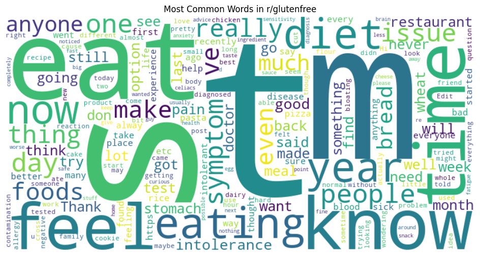

```python
#Most common words in r/glutenfree subreddit using WordCloud
#filter out STOPWORDS, since we obviously know they will appear frequently
from wordcloud import WordCloud, STOPWORDS
import matplotlib.pyplot as plt

# Filter for r/glutenfree posts
gf_posts = reddit_data[reddit_data['subreddit_name'].str.lower() == 'glutenfree']['body'].dropna().astype(str)

# Combine all posts into one string
text = ' '.join(gf_posts)

# Optional: add custom stopwords
custom_stopwords = set(STOPWORDS)
custom_stopwords.update(['glutenfree', 'gluten', 'gf', 'food', 'like', 'just', 'get', 'celiac', 'free'])  # add/remove as needed

# Generate the word cloud
wordcloud = WordCloud(width=800, height=400, background_color='white',
                      stopwords=custom_stopwords, collocations=False).generate(text)

# Display the word cloud
plt.figure(figsize=(12, 6))
plt.imshow(wordcloud, interpolation='bilinear')
plt.axis('off')
plt.title('Most Common Words in r/glutenfree')
plt.show()
```